# Lab 2 - Aprendizaje No Supervisado

### Test de Esfericidad de Bartlett

```r
bart_spher(datos_num)
```

```
##  Bartlett's Test of Sphericity
##
## Call: bart_spher(x = datos_num)
##
##      X2 = 105995.949
##      df = 66
## p-value < 2.22e-16
```

El test de Bartlett evalúa si la matriz de correlaciones es significativamente diferente a la identidad (H0: las variables no están correlacionadas). Un **p-valor < 0.05** rechaza H0 y confirma que el PCA es apropiado para estos datos, ya que existen correlaciones significativas que pueden resumirse en componentes.

## 2.3 Análisis de Componentes Principales

```r
datos_std <- scale(datos_num)
compPrinc <- prcomp(datos_std)
summary(compPrinc)
```

```
## Importance of components:
##                           PC1    PC2    PC3     PC4    PC5     PC6     PC7
## Standard deviation     2.1418 1.2910 1.1465 0.97692 0.8708 0.78923 0.74845
## Proportion of Variance 0.3823 0.1389 0.1095 0.07953 0.0632 0.05191 0.04668
## Cumulative Proportion  0.3823 0.5212 0.6307 0.71024 0.7734 0.82535 0.87203
##                            PC8    PC9    PC10    PC11    PC12
## Standard deviation     0.68989 0.6293 0.55585 0.43653 0.40521
## Proportion of Variance 0.03966 0.0330 0.02575 0.01588 0.01368
## Cumulative Proportion  0.91169 0.9447 0.97044 0.98632 1.00000
```

### Scree Plot

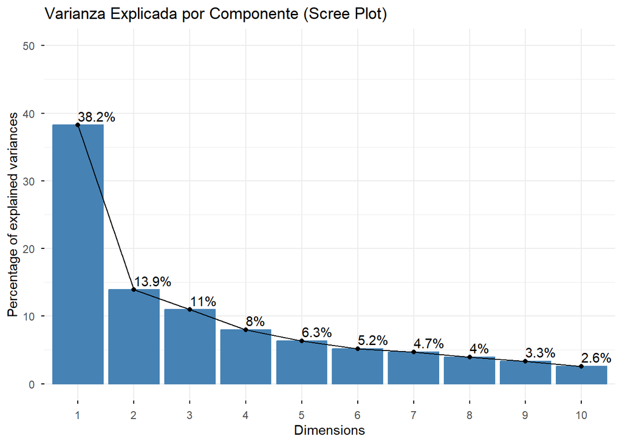

```r
fviz_eig(compPrinc,
         addlabels = TRUE,
         ylim = c(0, 50),
         main = "Varianza Explicada por Componente (Scree Plot)")
```

### Criterio de selección de componentes

Se seleccionan los componentes que: 1. Tienen **autovalor > 1** (criterio de Kaiser), y/o  
2. Explican acumulativamente **≥ 70-80%** de la varianza total.